# Homework Assignment 5

Justin Frisby

11 June 2021

```r
library(knitr)
library(tidyverse)
library(dplyr)
knitr::opts_chunk$set(echo = TRUE)
```

$~$

$~$

# 1 Read in the data

```r
Week_5_wd <-  file.path('/Users/justinfrisby/Desktop/dev/R/school/hds500/week5/')
df_dm_data <- read.csv(paste(Week_5_wd,'diabetic_data.csv', sep = ""))
df_mapping_data <- read.csv(paste(Week_5_wd,'IDs_mapping.csv', sep = ""))
```

The mapping file has multiple mapping tables inside of it, here I break the tables up by the empty rows and assign them to be their own mapping dataframes.

```r
empty_rows <- rowSums(df_mapping_data == "")==ncol(df_mapping_data)
indiv_mapping_dfs <- split(subset(df_mapping_data,!empty_rows),cumsum(empty_rows)[!empty_rows])

df_admit_type <- indiv_mapping_dfs[[1]][-1,] %>%
  rename( "AdmissionType" = "description")
df_disch_disp <- indiv_mapping_dfs[[2]][-1,] %>%
  rename("discharge_disposition_id" = "admission_type_id",
         "DischargeDisposition" = "description")
df_admit_sourc <- indiv_mapping_dfs[[3]][-1,] %>%
  rename("admission_source_id" = "admission_type_id",
         "AdmissionSource" = "description")

df_admit_sourc$admission_source_id <- as.integer(df_admit_sourc$admission_source_id )
df_admit_type$admission_type_id <- as.integer(df_admit_type$admission_type_id )
df_disch_disp$discharge_disposition_id <- as.integer(df_disch_disp$discharge_disposition_id )
```

Join the lookup values from the mapping dataframes, filter out the death & hospice dispositions and select the first encounter for each patient with multiple encounters. I used min encounter id to select the first encounter.

```r
df_joined <- df_dm_data %>%
  left_join(df_admit_type) %>%
  left_join(df_disch_disp) %>%
  left_join(df_admit_sourc)
df_joined <- df_joined %>%
  group_by(patient_nbr) %>%
  slice(which.min(encounter_id)) %>%
  filter(!DischargeDisposition %in% c("Hospice / medical facility","Expired","Expired at home. Medicaid only, hospice.","Expired in a medical facility. Medicaid only, hospice.","Hospice / home","Hospice / medical facility"))
glimpse(df_joined)
```

```
## Rows: 69,973
## Columns: 53
## Groups: patient_nbr [69,973]
## $ encounter_id             <int> 24437208, 29758806, 189899286, 64331490, 1482…
## $ patient_nbr              <int> 135, 378, 729, 774, 927, 1152, 1305, 1314, 16…
## $ race                     <chr> "Caucasian", "Caucasian", "Caucasian", "Cauca…
## $ gender                   <chr> "Female", "Female", "Female", "Female", "Fema…
## $ age                      <chr> "[50-60)", "[50-60)", "[80-90)", "[80-90)", "…
## $ weight                   <chr> "?", "?", "?", "?", "?", "?", "?", "?", "[50-…
## $ admission_type_id        <int> 2, 3, 1, 1, 1, 1, 3, 2, 3, 2, 2, 3, 1, 3, 1, …
## $ discharge_disposition_id <int> 1, 1, 3, 1, 1, 1, 1, 1, 6, 3, 1, 1, 1, 5, 3, …
## $ admission_source_id      <int> 1, 1, 7, 7, 7, 7, 1, 1, 4, 1, 1, 1, 7, 1, 7, …
## $ time_in_hospital         <int> 8, 2, 4, 3, 5, 6, 9, 2, 14, 12, 8, 1, 2, 7, 7…
## $ payer_code               <chr> "?", "?", "MC", "?", "?", "?", "?", "?", "MC"…
## $ medical_specialty        <chr> "Cardiology", "Surgery-Neuro", "InternalMedic…
```

[output cut: 41 more lines]

Creating calculated fields and renaming levels:

```r
df_joined <- df_joined %>%
  mutate(Discharge = if_else(DischargeDisposition == "Discharged to home", "Home", "Other"),
         Race2 = case_when(race == "AfricanAmerican" ~ "African American",
                           race == "Caucasian" ~ "Caucasian",
                           race == "?" ~ "Missing",
                           race %in% c("Hispanic","Asian","Other") ~ "Other"),
         Admission = case_when(AdmissionSource == " Emergency Room" ~ "Emergency Room",
                               AdmissionSource %in% c(" Physician Referral","HMO Referral") ~ "Referral",
                               TRUE ~ "Other"),
         medical_Specialty_2 = case_when(medical_specialty == "Cardiology" ~ "Cardiology",
                               medical_specialty == "Family/GeneralPractice" ~ "General Practice",
                               medical_specialty == "InternalMedicine" ~ "Internal Medicine",
                               medical_specialty == "?" ~ "Missing",
                               grepl("Surgery", medical_specialty) ~ "Surgery",
                               TRUE ~ "Other"),
         Age_2 = case_when(age %in% c("[0-10)","[20-30)") ~ "<30",
                           age %in% c("[30-40)","[40-50)","[50-60)") ~ "[30,60)",
                           TRUE ~ "[60,100)"),
         Diagnosis1_code = as.integer(if_else(diag_1 == "?", "000",gsub("[.]","",str_extract(diag_1, "[0-9]+.?")))),
         Diagnosis = case_when(
                        ((Diagnosis1_code >= 390 & Diagnosis1_code <= 459) | Diagnosis1_code == 785) ~ "Circulatory",
                        ((Diagnosis1_code >= 520 & Diagnosis1_code <= 579) | Diagnosis1_code == 787) ~ "Digestive",
                        ((Diagnosis1_code >= 580 & Diagnosis1_code <= 629) | Diagnosis1_code == 788) ~ "Genitourinary",
                        ((Diagnosis1_code >= 800 & Diagnosis1_code <= 998) | Diagnosis1_code == 999) ~ "Injury",
                      ((Diagnosis1_code >= 710 & Diagnosis1_code <= 738) | Diagnosis1_code == 739) ~ "Musculoskeletal",
                      ((Diagnosis1_code >= 140 & Diagnosis1_code <= 238) | Diagnosis1_code == 239) ~ "Neoplasms",
                      ((Diagnosis1_code >= 460 & Diagnosis1_code <= 519) | Diagnosis1_code == 786) ~ "Respiratory",
                      Diagnosis1_code == 250 ~ "Diabetes",
                      TRUE ~ "Other"),
         HbA1c = case_when(
                        (A1Cresult == ">8" & change == "Ch") ~ "High, changed",
                        (A1Cresult == ">8" & change == "No") ~ "High, not changed",
                        (A1Cresult == ">7" | A1Cresult == "Norm") ~ "Normal",
                      TRUE ~ "Not Measured"),
         WasReadmitted = if_else(readmitted == "<30","Yes","No")
)
```

Transform all variables to factors and setting factor reference based on reference levels in the paper:

```r
df_features <- df_joined %>%
  select(patient_nbr, WasReadmitted, Discharge, Admission, Race2, medical_Specialty_2, Age_2, Diagnosis, HbA1c, time_in_hospital, gender)
feature_cols <- c('WasReadmitted', 'Discharge', 'Admission', 'Race2', 'medical_Specialty_2','Age_2', 'Diagnosis', 'HbA1c', 'gender')
df_features[,feature_cols] <- lapply(df_features[,feature_cols], as.factor)

df_features$WasReadmitted <- relevel(df_features$WasReadmitted, ref = "No")
df_features$Discharge <- relevel(df_features$Discharge, ref = "Home")
df_features$Admission <- relevel(df_features$Admission, ref = "Emergency Room")
df_features$Race2 <- relevel(df_features$Race2, ref = "African American")
df_features$medical_Specialty_2 <- relevel(df_features$medical_Specialty_2, ref = "Cardiology")
df_features$Age_2 <- relevel(df_features$Age_2, ref = "[30,60)")
df_features$Diagnosis <- relevel(df_features$Diagnosis, ref = "Diabetes")
df_features$HbA1c <- relevel(df_features$HbA1c, ref = "Not Measured")
df_features$gender <- relevel(df_features$gender, ref = "Female")
```

```r
## Create Table 2

table_2 <- df_features %>%
  group_by(Diagnosis) %>%
  summarise(Number_of_Encounters = n())%>%
  mutate(Pct_of_encounters = (Number_of_Encounters / nrow(df_features))*100) %>%
  arrange(desc(Pct_of_encounters))

target_row = table_2 %>% filter(Diagnosis == "Other")

table_2 <- table_2 %>% filter(Diagnosis != "Other")

table_2_final <- rbind(table_2,target_row)
```

Recreate Table 3 from the paper: This includes the same variables except for the continuous age variable which was not provided.

```r
## Create Table 3

table_3 <- arsenal::tableby(WasReadmitted ~ HbA1c + gender + Discharge + Admission +
                                  medical_Specialty_2 +  Diagnosis + Race2 + Age_2 +
                                   time_in_hospital
                            , data = df_features)
# Rename variables
summary(table_3)
```

```
##
##
## |                                    |  No (N=63696)  |  Yes (N=6277)  | Total (N=69973) | p value|
## |:-----------------------------------|:--------------:|:--------------:|:---------------:|-------:|
## |**HbA1c**                           |                |                |                 |   0.021|
## |&nbsp;&nbsp;&nbsp;Not Measured      | 51929 (81.5%)  |  5199 (82.8%)  |  57128 (81.6%)  |        |
## |&nbsp;&nbsp;&nbsp;High, changed     |  3710 (5.8%)   |   348 (5.5%)   |   4058 (5.8%)   |        |
## |&nbsp;&nbsp;&nbsp;High, not changed |  2020 (3.2%)   |   161 (2.6%)   |   2181 (3.1%)   |        |
## |&nbsp;&nbsp;&nbsp;Normal            |  6037 (9.5%)   |   569 (9.1%)   |   6606 (9.4%)   |        |
## |**gender**                          |                |                |                 |   0.737|
## |&nbsp;&nbsp;&nbsp;Female            | 33868 (53.2%)  |  3361 (53.5%)  |  37229 (53.2%)  |        |
## |&nbsp;&nbsp;&nbsp;Male              | 29825 (46.8%)  |  2916 (46.5%)  |  32741 (46.8%)  |        |
## |&nbsp;&nbsp;&nbsp;Unknown/Invalid   |    3 (0.0%)    |    0 (0.0%)    |    3 (0.0%)     |        |
## |**Discharge**                       |                |                |                 | < 0.001|
## |&nbsp;&nbsp;&nbsp;Home              | 41239 (64.7%)  |  3078 (49.0%)  |  44317 (63.3%)  |        |
## |&nbsp;&nbsp;&nbsp;Other             | 22457 (35.3%)  |  3199 (51.0%)  |  25656 (36.7%)  |        |
## |**Admission**                       |                |                |                 |   0.023|
## |&nbsp;&nbsp;&nbsp;Emergency Room    | 33814 (53.1%)  |  3446 (54.9%)  |  37260 (53.2%)  |        |
## |&nbsp;&nbsp;&nbsp;Other             |  9890 (15.5%)  |  941 (15.0%)   |  10831 (15.5%)  |        |
## |&nbsp;&nbsp;&nbsp;Referral          | 19992 (31.4%)  |  1890 (30.1%)  |  21882 (31.3%)  |        |
## |**medical_Specialty_2**             |                |                |                 | < 0.001|
## |&nbsp;&nbsp;&nbsp;Cardiology        |  3905 (6.1%)   |   302 (4.8%)   |   4207 (6.0%)   |        |
## |&nbsp;&nbsp;&nbsp;General Practice  |  4493 (7.1%)   |   485 (7.7%)   |   4978 (7.1%)   |        |
## |&nbsp;&nbsp;&nbsp;Internal Medicine |  9602 (15.1%)  |  1039 (16.6%)  |  10641 (15.2%)  |        |
## |&nbsp;&nbsp;&nbsp;Missing           | 30535 (47.9%)  |  3104 (49.5%)  |  33639 (48.1%)  |        |
## |&nbsp;&nbsp;&nbsp;Other             | 11769 (18.5%)  |  1054 (16.8%)  |  12823 (18.3%)  |        |
## |&nbsp;&nbsp;&nbsp;Surgery           |  3392 (5.3%)   |   293 (4.7%)   |   3685 (5.3%)   |        |
## |**Diagnosis**                       |                |                |                 | < 0.001|
## |&nbsp;&nbsp;&nbsp;Diabetes          |  5224 (8.2%)   |   524 (8.3%)   |   5748 (8.2%)   |        |
## |&nbsp;&nbsp;&nbsp;Circulatory       | 19317 (30.3%)  |  2067 (32.9%)  |  21384 (30.6%)  |        |
## |&nbsp;&nbsp;&nbsp;Digestive         |  5967 (9.4%)   |   520 (8.3%)   |   6487 (9.3%)   |        |
## |&nbsp;&nbsp;&nbsp;Genitourinary     |  3131 (4.9%)   |   309 (4.9%)   |   3440 (4.9%)   |        |
## |&nbsp;&nbsp;&nbsp;Injury            |  4189 (6.6%)   |   506 (8.1%)   |   4695 (6.7%)   |        |
## |&nbsp;&nbsp;&nbsp;Musculoskeletal   |  3723 (5.8%)   |   341 (5.4%)   |   4064 (5.8%)   |        |
## |&nbsp;&nbsp;&nbsp;Neoplasms         |  2308 (3.6%)   |   230 (3.7%)   |   2538 (3.6%)   |        |
## |&nbsp;&nbsp;&nbsp;Other             | 11042 (17.3%)  |  1089 (17.3%)  |  12131 (17.3%)  |        |
## |&nbsp;&nbsp;&nbsp;Respiratory       |  8795 (13.8%)  |  691 (11.0%)   |  9486 (13.6%)   |        |
## |**Race2**                           |                |                |                 | < 0.001|
## |&nbsp;&nbsp;&nbsp;African American  | 11532 (18.1%)  |  1093 (17.4%)  |  12625 (18.0%)  |        |
## |&nbsp;&nbsp;&nbsp;Caucasian         | 47491 (74.6%)  |  4801 (76.5%)  |  52292 (74.7%)  |        |
## |&nbsp;&nbsp;&nbsp;Missing           |  1777 (2.8%)   |   141 (2.2%)   |   1918 (2.7%)   |        |
## |&nbsp;&nbsp;&nbsp;Other             |  2896 (4.5%)   |   242 (3.9%)   |   3138 (4.5%)   |        |
## |**Age_2**                           |                |                |                 | < 0.001|
## |&nbsp;&nbsp;&nbsp;[30,60)           | 20296 (31.9%)  |  1573 (25.1%)  |  21869 (31.3%)  |        |
## |&nbsp;&nbsp;&nbsp;[60,100)          | 42212 (66.3%)  |  4618 (73.6%)  |  46830 (66.9%)  |        |
## |&nbsp;&nbsp;&nbsp;<30               |  1188 (1.9%)   |   86 (1.4%)    |   1274 (1.8%)   |        |
## |**time_in_hospital**                |                |                |                 | < 0.001|
## |&nbsp;&nbsp;&nbsp;Mean (SD)         | 4.222 (2.916)  | 4.797 (3.058)  |  4.273 (2.934)  |        |
## |&nbsp;&nbsp;&nbsp;Range             | 1.000 - 14.000 | 1.000 - 14.000 | 1.000 - 14.000  |        |
```

Split the filtered & cleaned data into test/train dataframes and train the logistic regression model with pairwise interactions to mimic the paper methods

```r
## Run GLM, binomial - Train
set.seed(123)
sample.patient_nbr <- sample(df_features$patient_nbr,
                      size = nrow(df_features)*.6,
                      replace = FALSE)
length(sample.patient_nbr)/nrow(df_features)
```

```
## [1] 0.5999886
```

```r
df_features.train <- df_features %>%
  filter(patient_nbr %in% sample.patient_nbr)
glimpse(df_features.train)
```

```
## Rows: 41,983
## Columns: 11
## Groups: patient_nbr [41,983]
## $ patient_nbr         <int> 378, 729, 927, 1152, 1305, 1314, 2025, 4302, 5337,…
## $ WasReadmitted       <fct> No, No, No, No, No, No, No, No, No, No, No, No, No…
## $ Discharge           <fct> Home, Other, Home, Home, Home, Home, Other, Home, …
## $ Admission           <fct> Referral, Emergency Room, Emergency Room, Emergenc…
## $ Race2               <fct> Caucasian, Caucasian, African American, African Am…
## $ medical_Specialty_2 <fct> Surgery, Internal Medicine, Internal Medicine, Oth…
## $ Age_2               <fct> "[30,60)", "[60,100)", "[30,60)", "[30,60)", "[60,…
## $ Diagnosis           <fct> Musculoskeletal, Injury, Genitourinary, Other, Res…
## $ HbA1c               <fct> "Not Measured", "Normal", "Not Measured", "Not Mea…
## $ time_in_hospital    <int> 2, 4, 5, 6, 9, 2, 12, 1, 7, 4, 1, 1, 4, 6, 4, 2, 1…
## $ gender              <fct> Female, Female, Female, Female, Female, Female, Fe…
```

```r
logit_mod.train <- glm(WasReadmitted ~ Discharge + Admission + Race2 +
                                  medical_Specialty_2 + Age_2 + Diagnosis +
                                  HbA1c + time_in_hospital + Age_2:medical_Specialty_2 +
                                    Diagnosis:Discharge + Race2:Discharge + Discharge:time_in_hospital
                                + medical_Specialty_2:Discharge + time_in_hospital:medical_Specialty_2 +
                                time_in_hospital:Diagnosis + HbA1c:Diagnosis
                 , data = df_features.train, family = binomial)
broom::tidy(logit_mod.train)
```

```
## # A tibble: 90 x 5
##    term                                 estimate std.error statistic  p.value
##    <chr>                                   <dbl>     <dbl>     <dbl>    <dbl>
##  1 (Intercept)                           -3.27      0.238    -13.7   8.80e-43
##  2 DischargeOther                         0.232     0.262      0.887 3.75e- 1
##  3 AdmissionOther                        -0.0583    0.0510    -1.14  2.53e- 1
##  4 AdmissionReferral                      0.0269    0.0422     0.637 5.24e- 1
##  5 Race2Caucasian                         0.0322    0.0626     0.515 6.07e- 1
##  6 Race2Missing                          -0.433     0.180     -2.40  1.64e- 2
##  7 Race2Other                            -0.273     0.136     -2.00  4.51e- 2
##  8 medical_Specialty_2General Practice    0.644     0.248      2.60  9.41e- 3
##  9 medical_Specialty_2Internal Medicine   0.625     0.227      2.75  5.94e- 3
## 10 medical_Specialty_2Missing             0.626     0.210      2.98  2.85e- 3
## # … with 80 more rows
```

```r
logit_model_errors <- logit_mod.train %>%
  broom::glance() %>%
  mutate(Model = "LR Model") %>%
  select (Model, AIC, BIC)

logit_model_train_scored <- df_features.train

logit_model_train_scored$probs <- predict(logit_mod.train,
                                     logit_model_train_scored,
                                     "response")
```

Test the GLM model on the test set

```r
## Run GLM, binomial - Test
df_features.test <- df_features %>%
  filter(!(patient_nbr %in% sample.patient_nbr))

logit_test_score <- df_features.test %>%
  mutate(model = "new_model")

logit_test_score$probs <- predict(logit_mod.train,logit_test_score, "response")
glimpse(logit_test_score)
```

```
## Rows: 27,990
## Columns: 13
## Groups: patient_nbr [27,990]
## $ patient_nbr         <int> 135, 774, 1629, 3069, 5220, 6174, 8154, 8208, 8460…
## $ WasReadmitted       <fct> Yes, No, No, No, No, No, No, No, No, No, No, No, N…
## $ Discharge           <fct> Home, Home, Other, Home, Home, Other, Home, Home, …
## $ Admission           <fct> Referral, Emergency Room, Other, Referral, Emergen…
## $ Race2               <fct> Caucasian, Caucasian, Caucasian, Caucasian, Caucas…
## $ medical_Specialty_2 <fct> Cardiology, Internal Medicine, Missing, Cardiology…
## $ Age_2               <fct> "[30,60)", "[60,100)", "[60,100)", "[60,100)", "[6…
## $ Diagnosis           <fct> Circulatory, Other, Other, Circulatory, Other, Oth…
## $ HbA1c               <fct> "Not Measured", "High, changed", "Not Measured", "…
## $ time_in_hospital    <int> 8, 3, 14, 8, 2, 7, 1, 1, 2, 4, 2, 7, 6, 11, 1, 1, …
## $ gender              <fct> Female, Female, Male, Male, Male, Female, Female, …
## $ model               <chr> "new_model", "new_model", "new_model", "new_model"…
## $ probs               <dbl> 0.07411816, 0.07151305, 0.12676081, 0.12177399, 0.…
```

```r
logit_mod.prob_sum <- logit_model_train_scored %>%
  group_by(WasReadmitted) %>%
  summarise(min_prob = min(probs),
            mean_prob = mean(probs),
            max_prob = max(probs))

base_threshold_value <- (logit_mod.prob_sum %>% filter(WasReadmitted == "Yes"))$mean_prob

logit_test_score <- logit_test_score %>%
  mutate(pred = if_else(probs > base_threshold_value, "Yes", "No")) %>%
  mutate(pred_factor = as.factor(pred)) %>%
  mutate(pred_factor = fct_relevel(pred_factor, c('No','Yes') )) %>%
  mutate(correct_guess = if_else(pred_factor == WasReadmitted,TRUE,FALSE))
```

Create confusion matrix with additional model performance for the logistic regression model

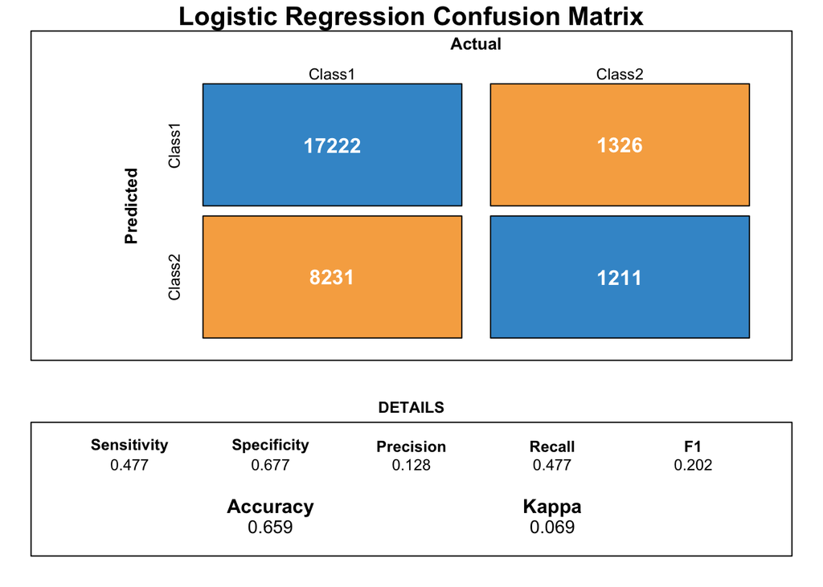

```r
## Plot LR Confusion Matrix
library(caret)
library(e1071)

logit_cm <- confusionMatrix(logit_test_score$pred_factor, logit_test_score$WasReadmitted, positive = "Yes")

draw_confusion_matrix <- function(cm, cm_title) {

  layout(matrix(c(1,1,2)))
  par(mar=c(2,2,2,2))
  plot(c(100, 345), c(300, 450), type = "n", xlab="", ylab="", xaxt='n', yaxt='n')
  title(cm_title, cex.main=2)

  # create the matrix
  rect(150, 430, 240, 370, col='#3F97D0')
  text(195, 435, 'Class1', cex=1.2)
  rect(250, 430, 340, 370, col='#F7AD50')
  text(295, 435, 'Class2', cex=1.2)
  text(125, 370, 'Predicted', cex=1.3, srt=90, font=2)
  text(245, 450, 'Actual', cex=1.3, font=2)
  rect(150, 305, 240, 365, col='#F7AD50')
  rect(250, 305, 340, 365, col='#3F97D0')
  text(140, 400, 'Class1', cex=1.2, srt=90)
  text(140, 335, 'Class2', cex=1.2, srt=90)

  # add in the cm results
  res <- as.numeric(cm$table)
  text(195, 400, res[1], cex=1.6, font=2, col='white')
  text(195, 335, res[2], cex=1.6, font=2, col='white')
  text(295, 400, res[3], cex=1.6, font=2, col='white')
  text(295, 335, res[4], cex=1.6, font=2, col='white')

  # add in the specifics
  plot(c(100, 0), c(100, 0), type = "n", xlab="", ylab="", main = "DETAILS", xaxt='n', yaxt='n')
  text(10, 85, names(cm$byClass[1]), cex=1.2, font=2)
  text(10, 70, round(as.numeric(cm$byClass[1]), 3), cex=1.2)
  text(30, 85, names(cm$byClass[2]), cex=1.2, font=2)
  text(30, 70, round(as.numeric(cm$byClass[2]), 3), cex=1.2)
  text(50, 85, names(cm$byClass[5]), cex=1.2, font=2)
  text(50, 70, round(as.numeric(cm$byClass[5]), 3), cex=1.2)
  text(70, 85, names(cm$byClass[6]), cex=1.2, font=2)
  text(70, 70, round(as.numeric(cm$byClass[6]), 3), cex=1.2)
  text(90, 85, names(cm$byClass[7]), cex=1.2, font=2)
  text(90, 70, round(as.numeric(cm$byClass[7]), 3), cex=1.2)

  # add in the accuracy information
  text(30, 35, names(cm$overall[1]), cex=1.5, font=2)
  text(30, 20, round(as.numeric(cm$overall[1]), 3), cex=1.4)
  text(70, 35, names(cm$overall[2]), cex=1.5, font=2)
  text(70, 20, round(as.numeric(cm$overall[2]), 3), cex=1.4)
}

draw_confusion_matrix(logit_cm, "Logistic Regression Confusion Matrix")
```

Construct a Random forest model to serve as an alternative to logistic regression model (THIS IS JUST EXPLORATORY! I created a “better” model below)

```r
## Run alt model
library("randomForest")
wy = sum(df_features.train$WasReadmitted=="Yes")/length(df_features.train$WasReadmitted)
wn = 1 - wy

rf <- randomForest(WasReadmitted ~ Discharge + Race2 +Age_2 + Diagnosis + HbA1c + gender + medical_Specialty_2,
                   data = df_features.train, classwt = c("Yes"=wy, "No"=wn))
rf
```

```
##
## Call:
##  randomForest(formula = WasReadmitted ~ Discharge + Race2 + Age_2 +      Diagnosis + HbA1c + gender + medical_Specialty_2, data = df_features.train,      classwt = c(Yes = wy, No = wn))
##                Type of random forest: classification
##                      Number of trees: 500
## No. of variables tried at each split: 2
##
##         OOB estimate of  error rate: 8.91%
## Confusion matrix:
##        No Yes class.error
## No  38243   0           0
## Yes  3740   0           1
```

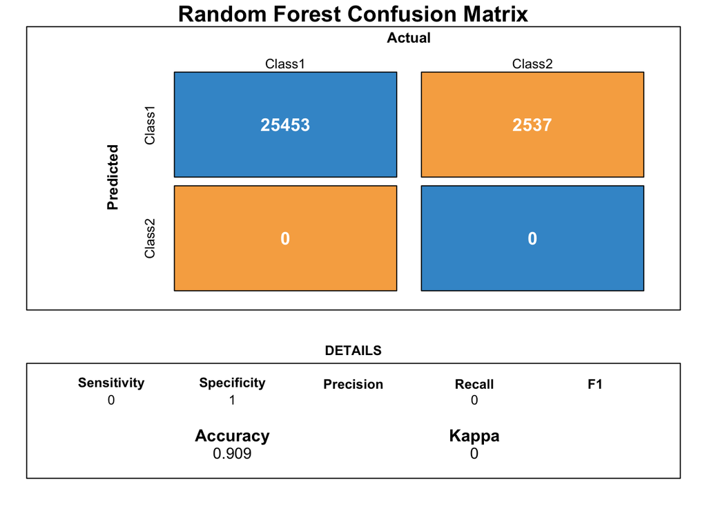

```r
rf.test.scored <- df_features.test %>%
  mutate(model="RF")

rf.test.scored$pred <- predict(rf, rf.test.scored, "response")
rf.test.scored <- rf.test.scored %>%
  mutate(pred_factor = as.factor(pred)) %>%
  mutate(pred_factor = fct_relevel(pred_factor, c('No','Yes') ))

rf_cm <- confusionMatrix(rf.test.scored$pred_factor, logit_test_score$WasReadmitted, positive = "Yes")
draw_confusion_matrix(rf_cm, "Random Forest Confusion Matrix")
```

This is a very interesting exercise to compare the differences between Rf and LR with a imbalanced outcome class. Superficially, the random forest model looks like a better model in terms of accuracy as it only predicts on class. By classifying all of the predictions as no, it is wrong on each actual readmission. Since there are only two classes, and the readmission class only makes up 8.9% of the outcomes, the RF model is too sensitive to the class imbalance and does not make predictions of readmission = “Yes”. The logistic regression model here would serve as the better model as it is not as sensitive to the class imbalance of the outcome variable.

I lead to believe that they did not split the data into test and train sets. When I run the LR model using a test train split, I get different estimates and p-values compared to running the LR model on the entire dataset. This is expected since the training sample is just that, a sample of the entire dataset. When running the LR model on the entire dataset, I get estimates that are much closer to the published values. I wonder if the difference is the differences in the training sample that we trained vs what they used, or if they fit the model on the entire dataset. Below are the estimates if I used the entire dataset instead of splitting into test/train which are much closer to what was reported in the manuscript.

```r
logit_mod.wholeDf <- glm(WasReadmitted ~ Discharge + Admission + Race2 +
                                  medical_Specialty_2 + Age_2 + Diagnosis +
                                  HbA1c + time_in_hospital + Age_2:medical_Specialty_2 +
                                    Diagnosis:Discharge + Race2:Discharge + Discharge:time_in_hospital
                                + medical_Specialty_2:Discharge + time_in_hospital:medical_Specialty_2 +
                                time_in_hospital:Diagnosis + HbA1c:Diagnosis
                 , data = df_features, family = binomial)
broom::tidy(logit_mod.wholeDf)
```

```
## # A tibble: 90 x 5
##    term                                 estimate std.error statistic  p.value
##    <chr>                                   <dbl>     <dbl>     <dbl>    <dbl>
##  1 (Intercept)                           -3.20      0.175    -18.2   3.18e-74
##  2 DischargeOther                         0.306     0.195      1.57  1.16e- 1
##  3 AdmissionOther                        -0.124     0.0398    -3.11  1.87e- 3
##  4 AdmissionReferral                     -0.0161    0.0326    -0.495 6.21e- 1
##  5 Race2Caucasian                         0.0166    0.0484     0.343 7.31e- 1
##  6 Race2Missing                          -0.313     0.134     -2.33  1.96e- 2
##  7 Race2Other                            -0.295     0.105     -2.82  4.86e- 3
##  8 medical_Specialty_2General Practice    0.412     0.184      2.23  2.56e- 2
##  9 medical_Specialty_2Internal Medicine   0.408     0.165      2.47  1.34e- 2
## 10 medical_Specialty_2Missing             0.429     0.150      2.86  4.21e- 3
## # … with 80 more rows
```

As the assignment was to create a “better” model, below is a LR with different features. I chose to eliminate all of the interactions and include the number of diagnosis, number of outpatient visits (to simulate IM/FM followup adherence which would hypothetically lead to better disease management), and if the patient is taking a DM medication.

```r
df_features_2 <- df_joined %>%
  select(patient_nbr, WasReadmitted, Discharge, Admission, Race2, medical_Specialty_2, Age_2, Diagnosis, HbA1c, time_in_hospital, gender, number_diagnoses, number_outpatient, diabetesMed)
feature_cols <- c('WasReadmitted', 'Discharge', 'Admission', 'Race2', 'medical_Specialty_2','Age_2', 'Diagnosis', 'HbA1c', 'gender', 'diabetesMed')
df_features_2[,feature_cols] <- lapply(df_features_2[,feature_cols], as.factor)

df_features_2$WasReadmitted <- relevel(df_features_2$WasReadmitted, ref = "No")
df_features_2$Discharge <- relevel(df_features_2$Discharge, ref = "Home")
df_features_2$Admission <- relevel(df_features_2$Admission, ref = "Emergency Room")
df_features_2$Race2 <- relevel(df_features_2$Race2, ref = "African American")
df_features_2$medical_Specialty_2 <- relevel(df_features_2$medical_Specialty_2, ref = "Cardiology")
df_features_2$Age_2 <- relevel(df_features_2$Age_2, ref = "[30,60)")
df_features_2$Diagnosis <- relevel(df_features_2$Diagnosis, ref = "Diabetes")
df_features_2$HbA1c <- relevel(df_features_2$HbA1c, ref = "Not Measured")
df_features_2$gender <- relevel(df_features_2$gender, ref = "Female")
df_features_2$diabetesMed <- relevel(df_features_2$diabetesMed, ref = "No")

set.seed(123)
sample.patient_nbr <- sample(df_features_2$patient_nbr,
                      size = nrow(df_features)*.6,
                      replace = FALSE)
length(sample.patient_nbr)/nrow(df_features_2)
```

```
## [1] 0.5999886
```

```r
df_features_2.train <- df_features_2 %>%
  filter(patient_nbr %in% sample.patient_nbr)
glimpse(df_features_2.train)
```

```
## Rows: 41,983
## Columns: 14
## Groups: patient_nbr [41,983]
## $ patient_nbr         <int> 378, 729, 927, 1152, 1305, 1314, 2025, 4302, 5337,…
## $ WasReadmitted       <fct> No, No, No, No, No, No, No, No, No, No, No, No, No…
## $ Discharge           <fct> Home, Other, Home, Home, Home, Home, Other, Home, …
## $ Admission           <fct> Referral, Emergency Room, Emergency Room, Emergenc…
## $ Race2               <fct> Caucasian, Caucasian, African American, African Am…
## $ medical_Specialty_2 <fct> Surgery, Internal Medicine, Internal Medicine, Oth…
## $ Age_2               <fct> "[30,60)", "[60,100)", "[30,60)", "[30,60)", "[60,…
## $ Diagnosis           <fct> Musculoskeletal, Injury, Genitourinary, Other, Res…
## $ HbA1c               <fct> "Not Measured", "Normal", "Not Measured", "Not Mea…
## $ time_in_hospital    <int> 2, 4, 5, 6, 9, 2, 12, 1, 7, 4, 1, 1, 4, 6, 4, 2, 1…
## $ gender              <fct> Female, Female, Female, Female, Female, Female, Fe…
## $ number_diagnoses    <int> 3, 9, 3, 2, 9, 9, 9, 7, 9, 7, 8, 5, 9, 7, 6, 9, 5,…
## $ number_outpatient   <int> 0, 0, 0, 0, 0, 0, 0, 0, 0, 0, 0, 0, 0, 0, 0, 0, 0,…
## $ diabetesMed         <fct> No, Yes, Yes, Yes, Yes, Yes, Yes, No, Yes, No, Yes…
```

```r
logit_mod_2.train <- glm(WasReadmitted ~ Discharge + Admission + Race2 +
                                  medical_Specialty_2 + Age_2 + Diagnosis +
                                  HbA1c + time_in_hospital + number_outpatient
                                  + diabetesMed + number_diagnoses
                         # + Age_2:medical_Specialty_2 +
                         #            Diagnosis:Discharge + Race2:Discharge + Discharge:time_in_hospital
                         #        + medical_Specialty_2:Discharge + time_in_hospital:medical_Specialty_2 +
                         #        time_in_hospital:Diagnosis + HbA1c:Diagnosis
                 , data = df_features_2.train, family = binomial)
broom::tidy(logit_mod_2.train)
```

```
## # A tibble: 29 x 5
##    term                                 estimate std.error statistic   p.value
##    <chr>                                   <dbl>     <dbl>     <dbl>     <dbl>
##  1 (Intercept)                           -3.46      0.134    -25.8   1.27e-146
##  2 DischargeOther                         0.490     0.0380    12.9   4.82e- 38
##  3 AdmissionOther                        -0.0398    0.0511    -0.779 4.36e-  1
##  4 AdmissionReferral                      0.0338    0.0420     0.804 4.21e-  1
##  5 Race2Caucasian                        -0.0255    0.0467    -0.547 5.85e-  1
##  6 Race2Missing                          -0.239     0.122     -1.96  5.03e-  2
##  7 Race2Other                            -0.0606    0.0965    -0.628 5.30e-  1
##  8 medical_Specialty_2General Practice    0.405     0.103      3.94  8.23e-  5
##  9 medical_Specialty_2Internal Medicine   0.365     0.0936     3.90  9.53e-  5
## 10 medical_Specialty_2Missing             0.225     0.0867     2.59  9.58e-  3
## # … with 19 more rows
```

```r
logit_2_model_errors <- logit_mod_2.train %>%
  broom::glance() %>%
  mutate(Model = "LR New Model") %>%
  select (Model, AIC, BIC)

logit_model_2_train_scored <- df_features_2.train

logit_model_2_train_scored$probs <- predict(logit_mod_2.train,
                                     logit_model_2_train_scored,
                                     "response")


## Run NEW GLM, binomial - Test
df_features_2.test <- df_features_2 %>%
  filter(!(patient_nbr %in% sample.patient_nbr))

logit_2_test_score <- df_features_2.test %>%
  mutate(model = "new_model")

logit_2_test_score$probs <- predict(logit_mod_2.train,logit_2_test_score, "response")

logit_mod_2.prob_sum <- logit_model_2_train_scored %>%
  group_by(WasReadmitted) %>%
  summarise(min_prob = min(probs),
            mean_prob = mean(probs),
            max_prob = max(probs))

base_threshold_value_2 <- (logit_mod_2.prob_sum %>% filter(WasReadmitted == "Yes"))$mean_prob

logit_2_test_score <- logit_2_test_score %>%
  mutate(pred = if_else(probs > base_threshold_value_2, "Yes", "No")) %>%
  mutate(pred_factor = as.factor(pred)) %>%
  mutate(pred_factor = fct_relevel(pred_factor, c('No','Yes') )) %>%
  mutate(correct_guess = if_else(pred_factor == WasReadmitted,TRUE,FALSE))
```

Compare model errors

```r
rbind(logit_model_errors,logit_2_model_errors)
```

```
## # A tibble: 2 x 3
##   Model           AIC    BIC
##   <chr>         <dbl>  <dbl>
## 1 LR Model     24774. 25552.
## 2 LR New Model 24733. 24984.
```

Show new model confusion matrix

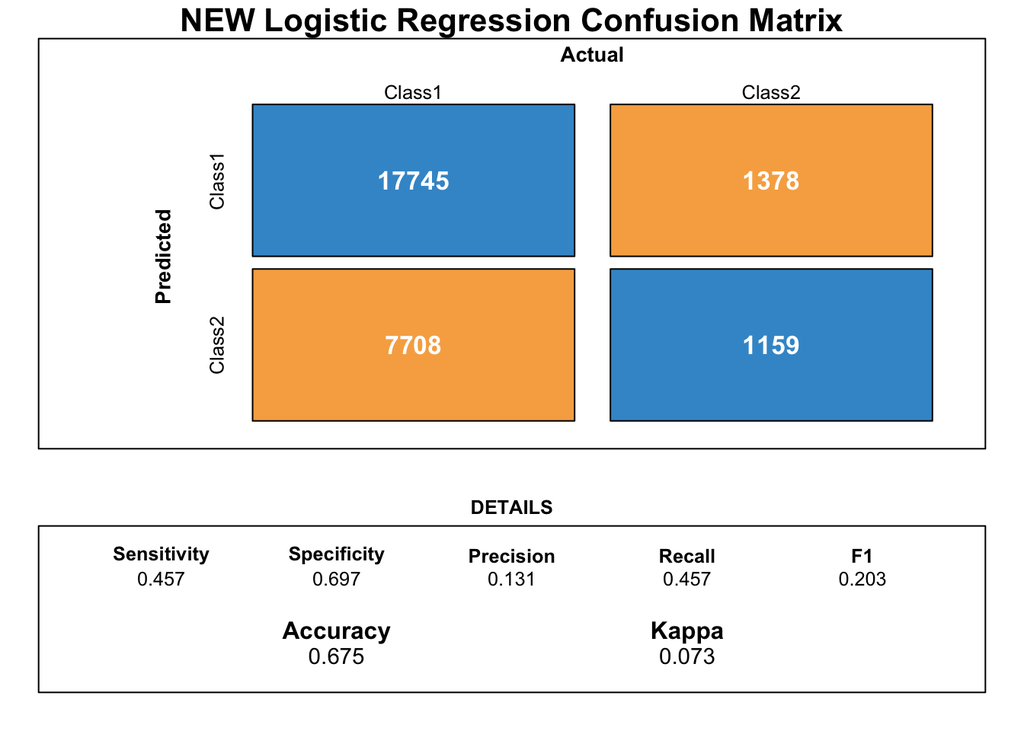

```r
logit_cm_2 <- confusionMatrix(logit_2_test_score$pred_factor, logit_2_test_score$WasReadmitted, positive = "Yes")
draw_confusion_matrix(logit_cm_2, "NEW Logistic Regression Confusion Matrix")
```

In conclusion, with the addition of the 3 features in the new model, the accuracy increased slightly (65.9 vs 67.5) and the AIC is lower (24774 vs 24733).